# Zaman Serileri Analizi Final

Irem Koyunlu 121517056

25 01 2021

# **ZAMAN SERILERI ANALIZI**

## *LONDRA HEATHROW YAGISLARI 2010-2019 HER GUN ICIN YAGIS VE ORTALAMA SICAKLIK*

### *Kaynak :https://www.kaggle.com/emafuma/ncei-heathrow-2010-2019*

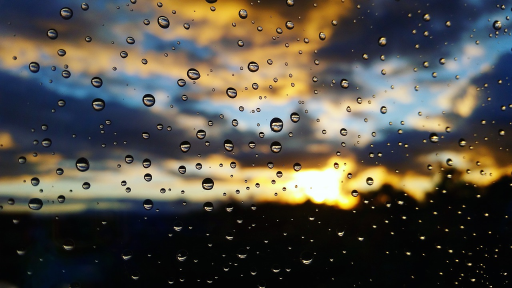

## *VERI SETI ACIKLAMASI;*

Heathrow Havalimani, Ingiltere’nin baskenti Londra’daki altinci ana havalimanindan biridir. Uluslararasi yolcu trafigine gore dunyanin en islek birinci, toplam yolcu trafigine gore ise dunyanin en islek ucuncu havalimanidir Londra’nin 20 mil batisindadir. Mevcut veri seti, Ocak 2010’den Aralik 2019’ye kadar Londra Heathrow’da her gun icin yagis ve ortalama gunluk sicakliklari sicakliklari icerir. Buradaki fikir, gercek veriler uzerinde kolay ama etkili gorsellestirmelerle deneyler icin kullanilacak cok basit bir zaman serisi veri kumesine sahip olmaktir. Veri seti Ulusal Cevresel Bilgi Merkezleri’nden (NCEI) indirilmistir.

## *DEGISKENLER;*

- **DATE:** Veri setimizdeki ilgilenilen tarih.
- **TAVG:** Veri setimizdeki ilgilenilen ortalama sicaklik.
- **PRCP:** Veri setimizdeki yagis miktari.

```r
library(readr)
library(dplyr)
library(fpp2)
temp <- read.csv("C:/Users/CASPER/Desktop/NCEI Heathrow Meteo Data 2010-2019.csv",header = T)

temp=temp%>%select(c("DATE","TAVG"))
head(temp,10)
```

```
##          DATE TAVG
## 1  2010-01-01  0.8
## 2  2010-01-02  1.8
## 3  2010-01-03  0.4
## 4  2010-01-04 -2.8
## 5  2010-01-05 -1.3
## 6  2010-01-06 -0.1
## 7  2010-01-07 -2.3
## 8  2010-01-08 -1.4
## 9  2010-01-09 -1.2
## 10 2010-01-10  1.4
```

Kullandigimiz verimizin summary kodu ile ozetini inceleyerek degisken turlerine bakalim;

```r
summary(temp)
```

```
##      DATE                TAVG
##  Length:3621        Min.   :-4.10
##  Class :character   1st Qu.: 7.40
##  Mode  :character   Median :11.60
##                     Mean   :11.64
##                     3rd Qu.:16.00
##                     Max.   :28.60
```

Kullandigimiz verimizdeki degiskenlerimizden olan DATE’ yi **lubridate** kodu ile Year ve Month olarak ayirip **group by** kodu ile gruplandiralim. Ayrica verimize gruplandirdigimiz sutunlari ekleyelim ve yeni **MonthTemp** verisini olusturalim;

```r
temp$Month<-lubridate::month(temp$DATE)
temp$Year<-lubridate::year(temp$DATE)
temp%>%group_by(Year,Month)%>%summarise(TAVG = mean(TAVG))->MonthTemp
head(MonthTemp,10)
```

```
## # A tibble: 10 x 3
## # Groups:   Year [1]
##     Year Month  TAVG
##    <dbl> <dbl> <dbl>
##  1  2010     1  2.18
##  2  2010     2  3.99
##  3  2010     3  7.06
##  4  2010     4 10.4
##  5  2010     5 12.3
##  6  2010     6 17.6
##  7  2010     7 19.4
##  8  2010     8 16.9
##  9  2010     9 14.8
## 10  2010    10 11.4
```

Year ve Month olarak ayirip gruplandirdigimiz yeni MonthTemp verimizin summary kodu ile ozetini inceleyerek degisken turlerine bakalim;

```r
summary(MonthTemp)
```

```
##       Year          Month            TAVG
##  Min.   :2010   Min.   : 1.00   Min.   : 1.429
##  1st Qu.:2012   1st Qu.: 3.75   1st Qu.: 7.108
##  Median :2014   Median : 6.50   Median :11.519
##  Mean   :2014   Mean   : 6.50   Mean   :11.594
##  3rd Qu.:2017   3rd Qu.: 9.25   3rd Qu.:16.017
##  Max.   :2019   Max.   :12.00   Max.   :21.803
```

Kullandigimiz verimiz icin MonthTemp olarak olusturdugumuz yeni verimiz aylik bir veri oldugu icin frequency degerimizi 12 alalim ve ts kodu ile aylik verimizi zaman serisine cevirelim;

```r
MonthTemp<-ts(MonthTemp[,3],start=c(2010,1),frequency =12)
MonthTemp
```

```
##            Jan       Feb       Mar       Apr       May       Jun       Jul
## 2010  2.183871  3.989286  7.064516 10.410000 12.312903 17.586667 19.448387
## 2011  5.083871  7.339286  7.625806 13.576667 13.874194 15.533333 16.864516
## 2012  6.593548  4.734483  9.177419  8.610000 13.619355 15.023333 16.916129
## 2013  4.551613  3.764286  3.819355  8.593333 11.777419 15.436667 20.580645
## 2014  7.006452  7.453571  8.948387 11.600000 13.687097 17.166667 19.912903
## 2015  5.516129  4.896429  7.625806  9.200000 12.793548 16.416667 18.309677
## 2016  6.448387  6.110345  6.819355  8.826667 13.935484 16.150000 18.729032
## 2017  4.003226  7.103571 10.058065 10.696667 14.512903 18.606667 18.870968
## 2018  6.674194  3.557143  6.045161 11.320000 14.964516 18.013333 21.803226
## 2019  4.977419  7.571429  9.345161 10.246667 13.100000 16.396667 19.987097
##            Aug       Sep       Oct       Nov       Dec
## 2010 16.877419 14.770000 11.438710  6.466667  1.429032
## 2011 16.948387 16.186667 13.622581 10.280000  7.019355
## 2012 18.325806 14.663333 10.929032  7.670000  5.880645
## 2013 18.851613 15.143333 13.445161  7.490000  7.109677
## 2014 16.529032 16.630000 13.829032  9.653333  6.196774
## 2015 17.796774 13.893333 12.112903 10.830000 11.374194
## 2016 19.096774 17.476667 11.619355  6.973333  6.883871
## 2017 17.303226 14.630000 13.538710  7.963333  5.990323
## 2018 18.777419 15.280000 11.974194  9.700000  7.941935
## 2019 19.041935 15.973333 11.722581  7.383333  7.077419
```

Kullandigimiz verimizde olusturdugumuz MonthTemp aylik verimiz icin Zaman Serisi Grafigimizi cizdirelim;

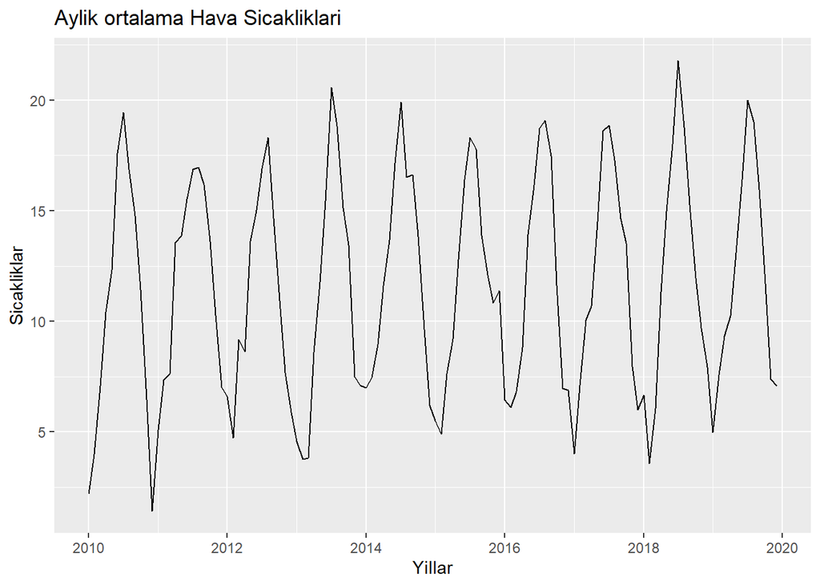

```r
library(fpp2)
autoplot(MonthTemp) +
ggtitle("Aylik ortalama Hava Sicakliklari") +
xlab("Yillar") +ylab("Sicakliklar")
```

Kullandigimiz verimizde olusturdugumuz MonthTemp aylik verimiz icin Zaman Serisi Grafigimize baktigimizda grafigimizde mevsimsellik oldugu gozukmektedir.Ayrica grafigimizde az da olsa artan trend oldugu gozukmektedir.

Kullandigimiz verimizde olusturdugumuz MonthTemp aylik verimizi test ve train olarak ikiye ayiralim;

```r
MonthTemp.train<-window(MonthTemp,end=c(2017,12))
MonthTemp.test<-window(MonthTemp, start=2018)
```

# **1.SORU**

- **Training setinizi lineer regresyon, lineer spline ve kubik spline regresyon yaklasimlarini kullanarak modelleyiniz.**

Kullandigimiz verimizde olusturdugumuz MonthTemp aylik verimiz icin olusturdugumuz **MonthTemp.train** setimize Lineer Regresyon Modeli , Lineer Spline Regresyon Modeli ve Cubic Spline Regresyon Modeli olusturalim;

- **Lineer Regresyon Modeli**

Kullandigimiz verimizde **MonthTemp.train** setimizi kullanarak Lineer Regresyon Modelini olusturmak icin tek bir lineer degisken kullanarak kurdugumuz lineer modeldelimizi tslm kodu ile olustururak trend tahmin degerine bakalim.Burada h degerini 10 alarak Lineer Regresyon Modelinin 10 adim ilerisi icin forecast tahminlerine bakalim;

```r
h <- 10
fit.lin <- tslm(MonthTemp.train ~ trend)
fc.lin <- forecast(fit.lin, h = h)
```

Olusturdugumuz Lineer Regresyon Modelimizdeki yani fit.lin’deki trend degerimize bakalim;

```r
fit.lin
```

```
##
## Call:
## tslm(formula = MonthTemp.train ~ trend)
##
## Coefficients:
## (Intercept)        trend
##    10.56963      0.01883
```

Olusturdugumuz Lineer Regresyon Modelimizdeki yani fit.lin’deki **trend** degerimize baktigimizda, trend degerimiz 0.01883 cikmistir yani pozitif bir trend gozukmektedir.

- **Lineer Spline Regresyon Modeli**

Kullandigimiz verimizde olusturdugumuz MonthTemp aylik verimiz icin olusturdugumuz **MonthTemp.train** setimizde uc farkli degisken **t** , **t.break1** ve **t.break2** yi ekleyip verimizi uc parcaya bolerek tslm kodu ile Lineer Spline Regresyon Modelimizi olusturalim.

Ekledigimiz t degiskeni 2014 e kadar olan yillar , t.break1 ve t.break2 degiskenleri kirilma noktalaridir.tb1 degiskeni 2014 ve 2017 arasindaki yillar ve tb2 degiskeni 2017 den sonraki yillari gostermektedir. Burada t.new, tb1.new ve tb2.new degiskenleri t,tb1 ve tb2 ye 10 adimlik tahminleri ekleyerek new data olarak data frame’e donusturulmus halleridir.

```r
t <- time(MonthTemp.train)
t.break1 <- 2014
t.break2 <- 2017
tb1 <- ts(pmax(0, t - t.break1), start = 2010)
tb2 <- ts(pmax(0, t - t.break2), start = 2010)

fit.pw <- tslm(MonthTemp.train ~ t + tb1 + tb2)
t.new <- t[length(t)] + seq(h)
tb1.new <- tb1[length(tb1)] + seq(h)
tb2.new <- tb2[length(tb2)] + seq(h)
newdata <- cbind(t=t.new, tb1=tb1.new, tb2=tb2.new) %>%
as.data.frame()
fc.pw <- forecast(fit.pw, newdata = newdata)
```

Olusturdugumuz Lineer Spline Regresyon Modelimizdeki yani fit.pw’deki trend degerlerimize bakalim;

```r
fit.pw
```

```
##
## Call:
## tslm(formula = MonthTemp.train ~ t + tb1 + tb2)
##
## Coefficients:
## (Intercept)            t          tb1          tb2
##   -726.9203       0.3668      -0.3933       1.3345
```

Ekledigimiz t degiskeni yani 2014 e kadar olan yillarin **trend** degeri 0.3668 cikmistir, **t** deki bir birimlik artis 0.3668’ lik artisa sebep olmaktadir.

tb1 degiskeni yani 2014 ve 2017 arasindaki yillarin **trend** degeri -0.3933 cikmistir, **tb1** deki bir birimlik artis 0.3933’luk azalisa sebep olmaktadir.

tb2 degiskeni yani 2017 den sonraki yillarin **trend** degeri 1.3345 cikmistir, **tb2** deki bir birimlik artis 1.3345’lik artisa sebep olmaktadir.

- **Cubic Spline Regresyon Modeli**

Kullandigimiz verimizde olusturdugumuz MonthTemp aylik verimiz icin olusturdugumuz **MonthTemp.train** setimize Cubic Spline Regresyon Modelini olusturalim;

```r
fit.spline <- tslm(MonthTemp.train ~ t + I(t^2) + I(t^3) +
I(tb1^3) + I(tb2^3))
fc.spl <- forecast(fit.spline, newdata = newdata)
```

## **A)**

- **Modelleri AICc kriterine gore kiyaslayip daha uygun oldugunu dusunduguniz modeli belirleyiniz.**
- **Lineer Regresyon Modelimizin AICc Degeri**

Kullandigimiz verimizde MonthTemp.train setimizi kullanarak olusturdugumuz Lineer Regresyon Modelimizin AICc degerine bakalim;

```r
CV(fit.lin)
```

```
##           CV          AIC         AICc          BIC        AdjR2
## 2.463378e+01 3.093790e+02 3.096399e+02 3.170721e+02 9.025280e-04
```

Kullandigimiz verimizde MonthTemp.train setimizi kullanarak olusturdugumuz Lineer Regresyon Modelimizin **AICc** degeri 3.096399e+02 cikmistir.

- **Lineer Spline Regresyon Modelimizin AICc Degeri**

Kullandigimiz verimizde MonthTemp.train setimizi kullanarak olusturdugumuz Lineer Spline Regresyon Modelimizin AICc degerine bakalim;

```r
CV(fit.pw)
```

```
##           CV          AIC         AICc          BIC        AdjR2
##  25.93054455 313.19543584 313.86210251 326.01717680  -0.01886674
```

Kullandigimiz verimizde MonthTemp.train setimizi kullanarak olusturdugumuz Lineer Spline Regresyon Modelimizin **AICc** degeri 313.86210251 cikmistir.

- **Cubic Spline Regresyon Modelimizin AICc Degeri**

Kullandigimiz verimizde MonthTemp.train setimizi kullanarak olusturdugumuz Cubic Spline Regresyon Modelimizin AICc degerine bakalim;

```r
CV(fit.spline)
```

```
##           CV          AIC         AICc          BIC        AdjR2
##  25.75904517 313.67913518 314.62295541 329.06522433  -0.01392125
```

Kullandigimiz verimizde MonthTemp train setimizi kullanarak olusturdugumuz Cubic Spline Regresyon Modelimizin **AICc** degeri 314.62295541 cikmistir.

Kullandigimiz verimizde **MonthTemp.train** setimizi kullanarak olusturdugumuz Lineer Regresyon Modelimizin ,Lineer Spline Regresyon Modelimizin ve Cubic Spline Regresyon Modelimizin AICc degerlerini karsilastirdigimizda AICc degeri en dusuk cikan modelimiz **Lineer Regresyon Modelimizdir**.

## **B)**

- **Uygun buldugunuz modeli kullanarak test setini tahmin ediniz ve tahminlere iliskin RMSE degerini hesaplayiniz.**

Kullandigimiz verimizde MonthTemp.train setimizi kullanarak olusturdugum Lineer Regresyon Modelimizin test setini tahmin edelim;

```r
forecast(fit.lin, h = h)-> fc.lin
fc.lin
```

```
##          Point Forecast    Lo 80    Hi 80    Lo 95    Hi 95
## Jan 2018       12.39629 5.930807 18.86177 2.449645 22.34293
## Feb 2018       12.41512 5.945517 18.88472 2.462136 22.36810
## Mar 2018       12.43395 5.960146 18.90776 2.474501 22.39340
## Apr 2018       12.45278 5.974693 18.93087 2.486742 22.41882
## May 2018       12.47161 5.989159 18.95407 2.498858 22.44437
## Jun 2018       12.49044 6.003544 18.97735 2.510849 22.47004
## Jul 2018       12.50928 6.017849 19.00070 2.522716 22.49584
## Aug 2018       12.52811 6.032073 19.02414 2.534459 22.52176
## Sep 2018       12.54694 6.046216 19.04766 2.546078 22.54780
## Oct 2018       12.56577 6.060279 19.07126 2.557574 22.57397
```

Kullandigimiz verimizde MonthTemp.train setimizi kullanarak olusturdugum Lineer Regresyon Modelimizin test setinin tahminlerine iliskin RMSE degerlerini hesaplayalim;

```r
accuracy(fc.lin,length(MonthTemp.test))
```

```
##                         ME      RMSE       MAE       MPE     MAPE     MASE
## Training set -3.330669e-16  4.855437  4.274361 -31.00309 56.47962 1.740154
## Test set      1.160371e+01 11.603713 11.603713  48.34880 48.34880 4.724040
##                   ACF1
## Training set 0.7944443
## Test set            NA
```

Kullandigimiz verimizde MonthTemp.train setimizi kullanarak olusturdugum Lineer Regresyon Modelimizin test setinin tahminlerine iliskin **RMSE** degeri 11.603713 cikmistir.

## **C)**

- **Uygun buldugunuz modelin hem training hem de test seti uzerindeki uyumunu gosteren zaman serisi grafigini cizdiriniz.**
- Kullandigimiz verimizde **MonthTemp.train** setimizi kullanarak olusturdugum Lineer Regresyon Modelimizin Zaman Serisi Grafigini cizdirelim;

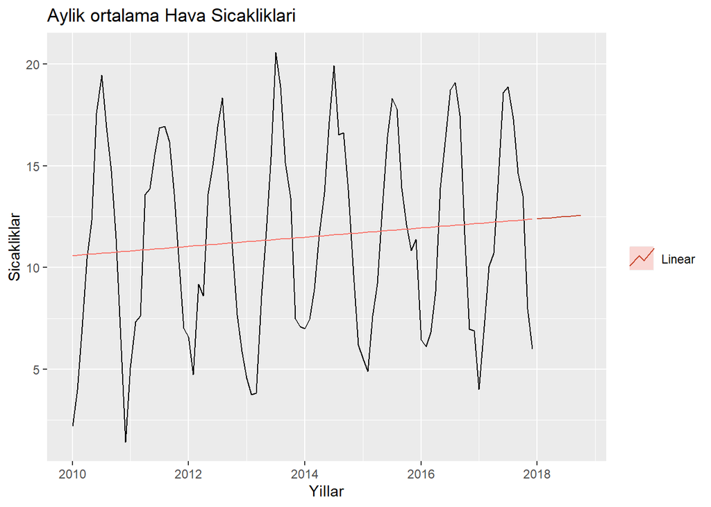

```r
autoplot(MonthTemp.train) +
autolayer(fitted(fit.lin), series = "Linear") +
autolayer(fc.lin, series="Linear", PI=FALSE)+
xlab("Yillar")+ylab("Sicakliklar")+
ggtitle("Aylik ortalama Hava Sicakliklari")+
guides(colour = guide_legend(title =" "))
```

Kullandigimiz verimizde **MonthTemp.train** setimizi kullanarak olusturdugum Lineer Regresyon Modelimizin Zaman Serisi Grafigini cizdirdigimizde lineer trendimizin tahmini lineer modeldeki tek bir trend degiskeni olan regresyon egrisini vermektedir.Grafikte de goruldugu gibi tahminler cok kaba tahminler yapmaktadir ve grafigimize baktigimizda az da olsa artan trend oldugu gozukmektedir.

- Oncelikle kullandigimiz verimizde **MonthTemp.test** setimizi kullanarak Lineer Regresyon Modelimizi olusturalim;

```r
fit.lintest <- tslm(MonthTemp.test ~ trend)
forecast(fit.lintest, h = h)-> fc.lintest
```

Kullandigimiz verimizde **MonthTemp.test** setimizi kullanarak olusturdugum Lineer Regresyon Modelimizin Zaman Serisi Grafigini cizdirelim;

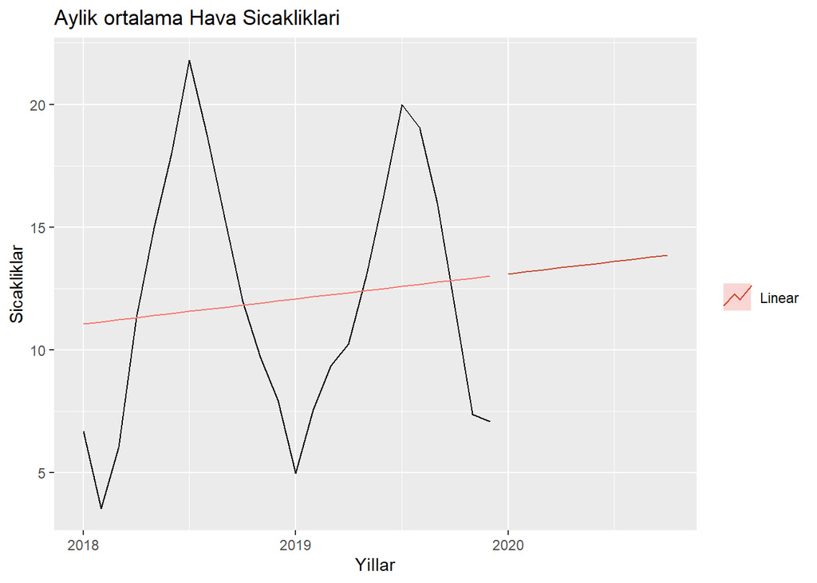

```r
autoplot(MonthTemp.test) +
autolayer(fitted(fit.lintest), series = "Linear") +
autolayer(fc.lintest, series="Linear", PI=FALSE)+
xlab("Yillar")+ylab("Sicakliklar")+
ggtitle("Aylik ortalama Hava Sicakliklari")+
guides(colour = guide_legend(title =" "))
```

Kullandigimiz verimizde **MonthTemp.test** setimizi kullanarak olusturdugum Lineer Regresyon Modelimizin Zaman Serisi Grafigini cizdirdigimizde lineer trendimizin tahmini lineer modeldeki tek bir trend degiskeni olan regresyon egrisini vermektedir.Grafikte de goruldugu gibi tahminler cok kaba tahminler yapmaktadir ve grafigimize baktigimizda az da olsa artan trend oldugu gozukmektedir.

## **D)**

- **Hatalara iliskin varsayimlari kontrol ediniz.**

Kullandigimiz verimize en uygun cikan modelimiz **Lineer Regresyon Modelimiz** ciktigindan,Lineer Regresyon Modelimizin artiklari icin checkresiduals komutu ile hatalara iliskin varsayimlari kontrol edelim;

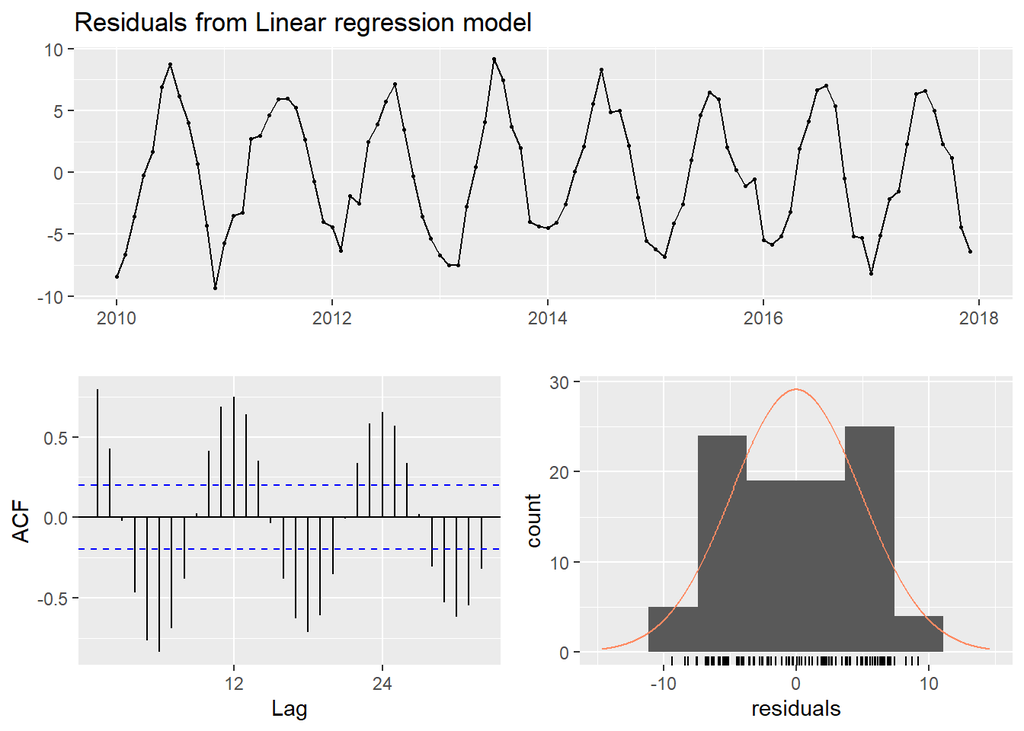

```
##
##  Breusch-Godfrey test for serial correlation of order up to 19
##
## data:  Residuals from Linear regression model
## LM test = 84.856, df = 19, p-value = 2.668e-10
```

```r
checkresiduals(fit.lin)
```

# **2.SORU**

## **A)**

- **Uygun hareketli ortalama (moving average) yontemini secip verinizin trend bilesenini belirleyiniz ve orijinal veri uzerinde grafikleyiniz.**

Kullandigimiz verimizde olusturdugumuz **MonthTemp** verimiz aylik bir veri oldugundan Moving Average m degerimizi 12 olarak alalim.Burada m degerini 1 aldigimiz zaman bize orijinal seriyi vermektedir. m degerimiz ne kadar yuksekse trend componentimiz o kadar duzlesmektedir ve hareketlilik azalmaktadir.

MonthTemp aylik verimiz icin **12-MA** alarak trend dongusunu gormek icin orijinal verilerle birlikte Moving Avarage Yonteminin Grafigini cizdirelim;

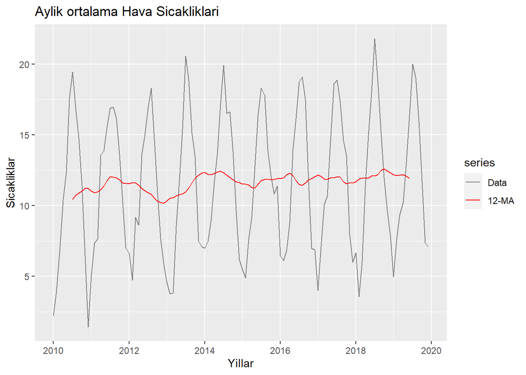

```r
autoplot(MonthTemp, series="Data") +
autolayer(ma(MonthTemp,12), series="12-MA") +
xlab("Yillar") + ylab("Sicakliklar") +
ggtitle("Aylik ortalama Hava Sicakliklari")+
scale_colour_manual(values=c("Data"="grey50","12-MA"="red"),
breaks=c("Data","12-MA"))
```

Egilim dongusu tahminlerin duzgunlugunu belirler ve ayni zamanda daha buyuk bir m daha yumusak bir egri anlamina gelir.Moving Avarage Yonteminin Grafigini inceledigimizde aylik verilerde egilim dongusunu yani trendi tahmin etmek icin 12-MA kullanildigindan trend tahmini genel olarak yapilamamistir.

## **B)**

- **Uygun STL ayristirmasi ile verinizi ayristirip grafikleyiniz.**
- **STL AYRISIMI**

mstl kodu, **s.window =13** kullanarak uygun bir otomatik STL ayristirma saglar ve t.window da otomatik olarak secilir.Bu genellikle mevsime fazla uyum saglamak ve zamanla yavasca degismesine izin vermek arasinda iyi bir denge saglar.

Kullandigimiz verimizde olusturdugumuz **MonthTemp** verimizde STL Ayrisimi yapmak icin mstl kodumuzu kullanarak fit.stl modelimizi olusturalim;

```r
MonthTemp %>% mstl(s.window=13, robust=TRUE) -> fit.stl
```

Kullandigimiz verimizde olusturdugumuz **MonthTemp** verimizde STL Ayrisimi yapmak icin **mstl** kodumuzu kullanarak olusturdugumu fit.stl modelimizin grafigini cizdirelim;

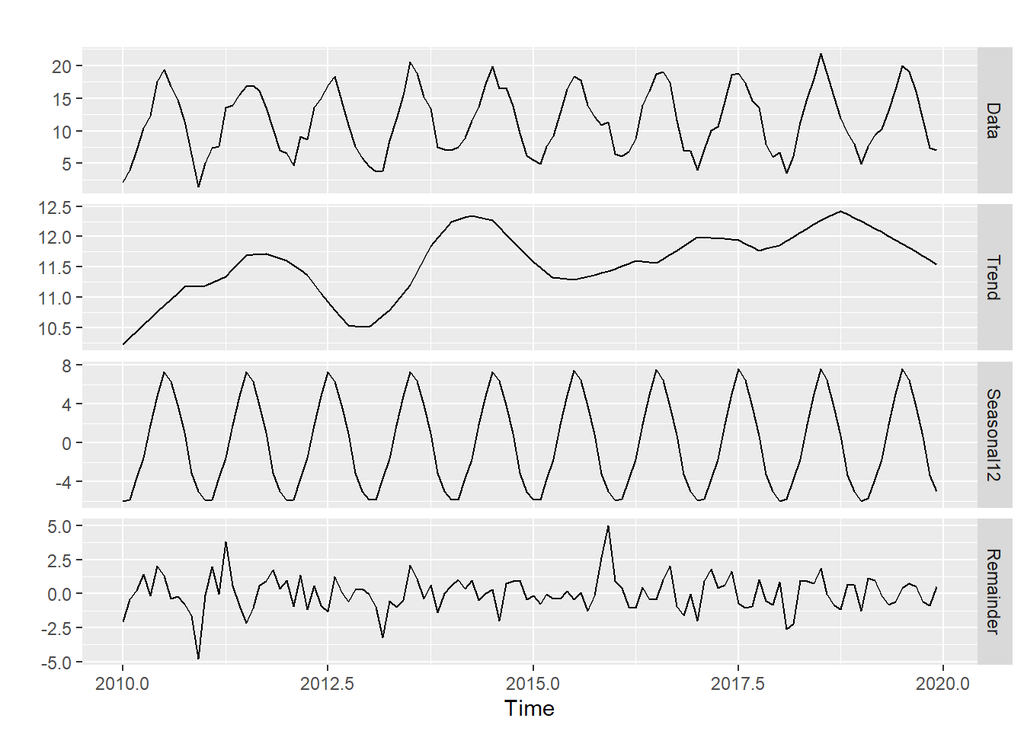

```r
autoplot(fit.stl)
```

- Kullandigimiz verimiz icin olusturdugumuz MonthTemp verimizde **STL Ayrisimi** yaptigimizda bu ayrisim mevsimsellik ve trendi net bir sekilde gormemizde ve verimizin yapisini incelememizde bize yardimci olur.
- Kullandigimiz verimiz icin olusturdugumuz MonthTemp verimizde cizdirdigimiz **Data Ciktimiz** orijinal serinin Zaman Serisi Grafigini yani autoplotunu vermektedir.Bu grafige baktigimizda mevsimselligin varligi gozukmektedir.
- Kullandigimiz verimiz icin olusturdugumuz MonthTemp verimizde cizdirdigimiz Moving Average ile olusturulan **Trend Ciktimiza** baktigimizda az da olsa artan bir trend oldugu gozukmektedir.
- Kullandigimiz verimiz icin olusturdugumuz MonthTemp verimizde cizdirdigimiz **Seasonal12 Ciktimiza** baktigimizda mevsimsellik oldugu gozukmektedir.Grafige baktigimizda mevsimselligin artis veya azalis gostermedigini yani mevsimselligin her yil sabit kaldigi gozukmektedir.
- Kullandigimiz verimiz icin olusturdugumuz MonthTemp verimizde cizdirdigimiz **Remainder Ciktimiza** baktigimizda aylik verimizden trend ve mevsimselligin cikarildigi zamanki verimizin grafigi gozukmektedir. Ayrica Remainder grafigi bize verimizin trend ve mevsimsellik tarafindan aciklanamayan kismini gostermektedir.

## **C)**

- **Verinizdeki trend ve mevsimsellik bilesenlerinin gucunu belirleyiniz.**

Kullandigimiz verimizde degisken varyanslilik heteroscedasticity problemi var ise yani zaman ile verinin varyasyonunda bir degisiklik oluyor ise carpimsallik soz konusudur,degisken varyanslilik heteroscedasticity problemi yok ise veride toplamsal bir ayrisim kullanilir.Soruda bizden degisken varyansliligi test etmemiz istenmedigi icin trend ve mevsimselligin gucunu iki sekilde de inceleyelim.

Kullandigimiz verimiz icin olusturdugumuz MonthTemp verimizdeki trend ve mevsimsellik bilesenlerinin gucunu belirlememiz icin;

Mevsimsel bilesenini belirlemek icin **seasonal** kodunu kullanalim;

```r
seasonal(fit.stl)->s
```

Trend bilesenini belirlemek icin **trendycyle** kodunu kullanalim;

```r
trendcycle(fit.stl)->t
```

Ramainder bilesenini belirlemek icin **remainder** kodunu kullanalim;

```r
remainder(fit.stl)->r
```

Kullandigimiz verimiz icin olusturdugumuz MonthTemp verimizdeki trend ve mevsimsellik bilesenlerinin degerlerine bakalim;

- **Toplamsal Trend Ve Toplamsal Mevsimsellik**

```r
ToplamsalTrend<-max(0, (1-(var(r)/var(t+r))))
ToplamsalTrend
```

```
## [1] 0.1878766
```

```r
ToplamsalMevsimsellik<-max(0, (1-(var(r)/var(s+r))))
ToplamsalMevsimsellik
```

```
## [1] 0.9305752
```

- Olusturdugumuz MonthTemp verimizde guclu bir toplamsal trend var ise toplamsal trend degerimizin sonucu 1’e daha yakin cikmalidir. Verimizdeki toplamsal trend degerimiz 0.1878766 olarak cikmistir. Bu deger 1’e yakin olmadigindan verimizde dusuk bir toplamsal trend vardir.
- Olusturdugumuz MonthTemp verimizde guclu bir toplamsal mevsimsellik var ise toplamsal mevsimsellik degerimizin sonucu 1’e daha yakin cikmalidir. Verimizdeki toplamsal mevsimsellik degerimiz 0.9305752 olarak cikmistir. Bu deger 1’e yakin oldugundan verimizde guclu bir toplamsal mevsimsellik vardir.
- **Carpimsal Trend Ve Carpimsal Mevsimsellik**

```r
CarpimsalTrend<-max(0, (1-(var(r)/var(t*r))))
CarpimsalTrend
```

```
## [1] 0.9924062
```

```r
CarpimsalMevsimsellik<-max(0, (1-(var(r)/var(s*r))))
CarpimsalMevsimsellik
```

```
## [1] 0.9562956
```

- Olusturdugumuz MonthTemp verimizde guclu bir carpimsal trend var ise carpimsal trend degerimizin sonucu 1’e daha yakin cikmalidir.Verimizdeki carpimsal trend degerimiz 0.9924062 olarak cikmistir. Bu deger 1’e yakin oldugundan verimizde guclu bir carpimsal trend vardir.
- Olusturdugumuz MonthTemp verimizde guclu bir carpimsal mevsimsellik var ise carpimsal mevsimsellik degerimizin sonucu 1’e daha yakin cikmalidir.Verimizdeki carpimsal mevsimsellik degerimiz 0.9562956 olarak cikmistir. Bu deger 1’e yakin oldugundan verimizde guclu bir carpimsal mevsimsellik vardir.

## **D)**

- **Training set uzerinde STL ayristirmasini kullanarak, test setinizi tahmin ediniz. Orijinal veri uzerine tahminlerinizi grafikleyip tahminlere iliskin RMSE degerini hesaplayiniz.**

Kullandigimiz verimizde **MonthTemp.train** setimiz uzerinde STL Ayrisimi yapmak icin mstl kodumuzu kullanarak train.fit.stl modelimizi olusturalim;

```r
MonthTemp.train %>% mstl(s.window=13, robust=TRUE) -> train.fit.stl
```

Kullandigimiz verimizde MonthTemp.train setimizi kullanarak olusturdugumuz STL Ayrisimi Modelimizin test setini tahmin edelim;

```r
fc.train.fit.stl<-forecast(train.fit.stl)
fc.train.fit.stl
```

```
##          Point Forecast     Lo 80     Hi 80     Lo 95     Hi 95
## Jan 2018       5.905677  3.993992  7.817363  2.982006  8.829349
## Feb 2018       6.047658  4.133356  7.961961  3.119985  8.975331
## Mar 2018       8.331163  6.414247 10.248078  5.399493 11.262832
## Apr 2018       9.884954  7.965429 11.804479  6.949294 12.820615
## May 2018      13.665107 11.742976 15.587238 10.725461 16.604752
## Jun 2018      16.690435 14.765702 18.615169 13.746810 19.634061
## Jul 2018      19.001936 17.074604 20.929269 16.054336 21.949537
## Aug 2018      18.158705 16.228777 20.088632 15.207135 21.110274
## Sep 2018      15.636505 13.703985 17.569024 12.680971 18.592038
## Oct 2018      12.908816 10.973708 14.843924  9.949323 15.868308
## Nov 2018       8.556192  6.618499 10.493885  5.592746 11.519638
## Dec 2018       6.613544  4.673269  8.553818  3.646150  9.580938
## Jan 2019       5.905677  3.962825  7.848530  2.934341  8.877014
## Feb 2019       6.047658  4.102231  7.993086  3.072384  9.022933
## Mar 2019       8.331163  6.383164 10.279161  5.351956 11.310369
## Apr 2019       9.884954  7.934388 11.835521  6.901820 12.868088
## May 2019      13.665107 11.711976 15.618238 10.678051 16.652163
## Jun 2019      16.690435 14.734743 18.646127 13.699462 19.681408
## Jul 2019      19.001936 17.043686 20.960186 16.007051 21.996821
## Aug 2019      18.158705 16.197900 20.119509 15.159913 21.157496
## Sep 2019      15.636505 13.673149 17.599860 12.633811 18.639198
## Oct 2019      12.908816 10.942912 14.874719  9.902226 15.915405
## Nov 2019       8.556192  6.587744 10.524640  5.545710 11.566673
## Dec 2019       6.613544  4.642555  8.584533  3.599176  9.627912
```

Kullandigimiz aylik MonthTemp verimiz yani orijinal verimiz uzerinde tahminlerinizi grafikleyelim;

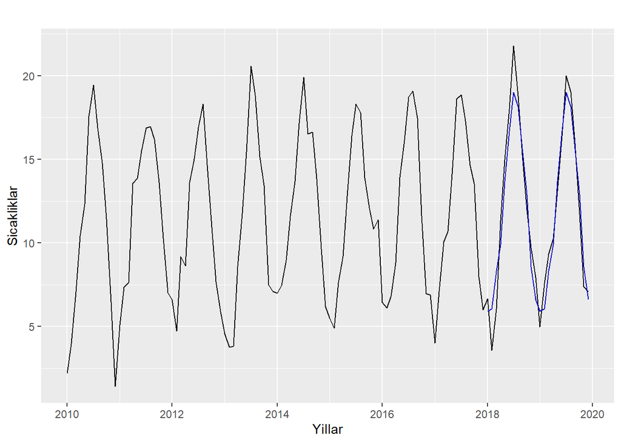

```r
autoplot(MonthTemp) +
autolayer(fc.train.fit.stl,PI=FALSE)+xlab("Yillar")+ylab("Sicakliklar")+guides(colour=guide_legend(title="Forecast"))
```

Kullandigimiz aylik MonthTemp verimiz yani orijinal verimiz uzerinde tahminlerinizin grafigini inceledigimizde; tahminlerimiz yani grafikte gozuken mavi cizgiler orijinal verimizin yani siyah cizgizlerin tam ustunde oldugu icin orijinal verimizi iyi tahmin etmistir.

Kullandigimiz verimizde MonthTemp.train setimizi kullanarak olusturdugumuz STL Ayrisimi Modelimizin tahminlerine iliskin RMSE degerlerini hesaplayalim;

```r
accuracy(fc.train.fit.stl,length(MonthTemp.test))
```

```
##                     ME      RMSE       MAE       MPE     MAPE      MASE
## Training set  0.151314  1.476076  1.137732 -4.587959 15.98990 0.4631871
## Test set     18.094323 18.094323 18.094323 75.393011 75.39301 7.3664619
##                   ACF1
## Training set 0.3098812
## Test set            NA
```

Kullandigimiz verimizde MonthTemp.train setimizi kullanarak olusturdugumuz STL Ayrisimi Modelimizin tahminlerine iliskin **RMSE** degerimiz 18.094323 cikmistir.